# S. cerevisiae genesets

## Initialization

We start the analysis by initializing the packages required in this section. We also define the root directory, within which all the input/output operations for this project will be performed. At the end of this document, a detailed software version information is provided for easier reproducibility of the analysis.

```r
library(data.table)
library(gridExtra)
library(KEGGREST)
library(ggplot2)
library(reshape2)
path = "/Users/ashwin/Documents/Projects/YeastScreen/Essential_DAmP_screen/"
```

## Slim gene ontology

Creating yeast (*Saccharomyces cerevisiae*) specific slim gene ontology based genesets. We create separate sets for `molecular function` and `biological process`. The data is obtained from [Saccharomyces Genome Database (SGD)](https://www.yeastgenome.org/). Keeping only those genesets having >= 5 and <= 500 genes.

```r
dat = read.delim("https://downloads.yeastgenome.org/curation/literature/go_slim_mapping.tab",
    header = F, stringsAsFactors = F)
colnames(dat) = c("ORF", "Gene", "SGDID", "GO_Aspect", "GOslim", "GOID", "Type")

bp = dat[dat$GO_Aspect == "P", ]
mf = dat[dat$GO_Aspect == "F", ]

createGoObj = function(godat) {
    godat = split(godat$Gene, godat$GOslim)
    godat = lapply(godat, function(x) {
        x = x[x != ""]
        x = unique(x)
        return(x)
    })

    return(godat)
}

bp = createGoObj(godat = bp)
cnt = sapply(bp, length)
bp = bp[cnt >= 5 & cnt <= 500]

mf = createGoObj(godat = mf)
cnt = sapply(mf, length)
mf = mf[cnt >= 5 & cnt <= 500]
```

## KEGG pathways

Creating yeast (*Saccharomyces cerevisiae*) specific KEGG pathway based genesets. The data is obtained from [Saccharomyces Genome Database (SGD)](https://www.yeastgenome.org/). Keeping only those gene sets having >= 5 and <= 500 genes.

```r
# metpath =
# read.delim(url('https://downloads.yeastgenome.org/curation/literature/biochemical_pathways.tab'),
# header = F, stringsAsFactors = F) colnames(metpath) = c('Pathway', 'Enzyme',
# 'ECnumber', 'Gene', 'Reference') metpath = metpath[- which(metpath$Gene ==
# ''),] metpath = split(metpath$Gene, metpath$Pathway) metpath =
# metpath[sapply(metpath, length) >= 3] yeastpath = metpath rm(metpath)

## Or KEEG pathways can be extracted from KEEG website directly

yeastpath = keggLink("pathway", "sce")
yeastpath = unique(yeastpath)

ind = seq(1, length(yeastpath), 10)
ind = data.frame(start = ind, end = c(c(ind[2:length(ind)] - 1), length(yeastpath)))

pathres = vector("list", length(yeastpath))

for (i in 1:nrow(ind)) {
    tmp = keggGet(yeastpath[ind[i, 1]:ind[i, 2]])
    pathres[ind[i, 1]:ind[i, 2]] = lapply(tmp, function(x) {
        x = grep(";", x$GENE, value = T)
        x = unique(sapply(strsplit(x, ";"), function(y) y[1]))
        return(x)
    })
    names(pathres)[ind[i, 1]:ind[i, 2]] = gsub(" - Saccharomyces cerevisiae (budding yeast)",
        "", sapply(tmp, function(x) {
            x = x$NAME
        }), fixed = T)
    rm(tmp)
}
yeastpath = pathres
rm(i, ind, pathres)

# Keeping only the pathways with at least 5 genes
cnt = sapply(yeastpath, length)
yeastpath = yeastpath[cnt >= 5 & cnt <= 500]
```

## Transcription fator targets

Creating yeast (*Saccharomyces cerevisiae*) specific transcription factor targets. The data is originally obtained from [TF2DNA database](http://www.fiserlab.org/tf2dna_db/). However, we use the data provided from [YeastEnrichr](https://amp.pharm.mssm.edu/YeastEnrichr/) which also based on TF2DNA but provides it in an easy-to-use format. Keeping only those gene sets having >= 5 and <= 1000 genes.

```r
if (!file.exists(paste0(path, "publicData/TF2DNA_2018.txt"))) {
    download.file(url = "https://amp.pharm.mssm.edu/YeastEnrichr/geneSetLibrary?mode=text&libraryName=TF2DNA_2018",
        destfile = paste0(path, "publicData/TF2DNA_2018.txt"))
}

tfs = readLines(paste0(path, "publicData/TF2DNA_2018.txt"))
tfs = lapply(as.list(tfs), function(x) {
    x = unique(unlist(strsplit(x, "\t", fixed = T)))
    x = x[!x == ""]
})
names(tfs) = sapply(tfs, function(x) x[1])
tfs = lapply(tfs, function(x) x[-1])

tfid = data.frame(study = names(tfs), tf = sapply(strsplit(names(tfs), "_"), function(x) x[1]),
    stringsAsFactors = F)
tfid = split(tfid$study, tfid$tf)

tfs = lapply(tfid, function(x) {
    x = Reduce(intersect, tfs[x])
})

cnt = sapply(tfs, length)
tfs = tfs[cnt >= 5 & cnt <= 1000]
```

## Yeast phenotypes

Creating yeast (*Saccharomyces cerevisiae*) specific gene phenotype information. The data is obtained from [Saccharomyces Genome Database (SGD)](https://www.yeastgenome.org/). Keeping only those gene sets having >= 5 and<= 1000 genes.

```r
pheno = read.delim("https://downloads.yeastgenome.org/curation/literature/phenotype_data.tab",
    header = F, stringsAsFactors = F)

pheno = pheno[, c(3, 6, 7, 10)]
colnames(pheno) = c("Gene", "Experiment", "MutantType", "Phenotype")

pheno = lapply(split(pheno$Gene, pheno$Phenotype), function(x) {
    x = x[x != ""]
    x = unique(x)
})
cnt = sapply(pheno, length)
pheno = pheno[cnt >= 5 & cnt <= 1000]
```

## Integrated yeast genesets

Here we combine the KEGG and GO slim genesets into one meta yeast geneset object

```r
genesets = list(KEGG = yeastpath, GOBP = bp, GOMF = mf, TFtargets = tfs, Phenotype = pheno)
saveRDS(genesets, file = paste0(path, "data/workspaces/YeastGeneSets.RDS"))
```

## Geneset description

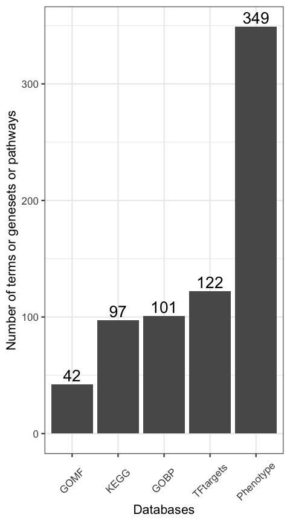

```r
tmp = lapply(genesets, length)
tmp = melt(tmp)

p = ggplot(tmp, aes(reorder(L1, value), value)) + theme_bw(base_size = 8) + labs(x = "Databases",
    y = "Number of terms or genesets or pathways") + geom_bar(stat = "identity") +
    geom_text(aes(label = value), vjust = -0.3, size = 3.5) + theme(axis.text.x = element_text(angle = 45,
    hjust = 0.5, vjust = 0.5))

ggsave(filename = paste0(path, "analysis/supplementary/Scerevisae_genesets.pdf"),
    plot = p, width = 4, height = 4)

p
```

The size of each of the gene sets, i.e. the number of genes per gene sets. Not showing phenotypes as the list is too big to display.

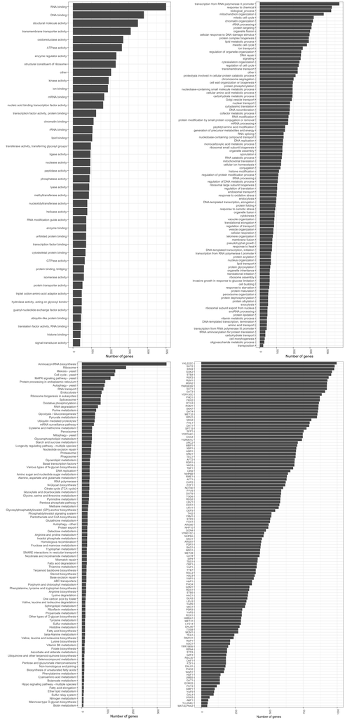

```r
tmp = lapply(genesets$GOMF, length)
tmp = melt(tmp)

p1 = ggplot(tmp, aes(reorder(L1, value), value)) + theme_bw(base_size = 9) + labs(x = "",
    y = "Number of genes") + geom_bar(stat = "identity") + coord_flip() + theme(axis.text.x = element_text(angle = 90))

tmp = lapply(genesets$GOBP, length)
tmp = melt(tmp)

p2 = ggplot(tmp, aes(reorder(L1, value), value)) + theme_bw(base_size = 9) + labs(x = "",
    y = "Number of genes") + geom_bar(stat = "identity") + coord_flip() + theme(axis.text.x = element_text(angle = 90))

tmp = lapply(genesets$KEGG, length)
tmp = melt(tmp)

p3 = ggplot(tmp, aes(reorder(L1, value), value)) + theme_bw(base_size = 9) + labs(x = "",
    y = "Number of genes") + geom_bar(stat = "identity") + coord_flip() + theme(axis.text.x = element_text(angle = 90))

tmp = lapply(genesets$TFtargets, length)
tmp = melt(tmp)

p4 = ggplot(tmp, aes(reorder(L1, value), value)) + theme_bw(base_size = 8) + labs(x = "",
    y = "Number of genes") + geom_bar(stat = "identity") + coord_flip() + theme(axis.text.x = element_text(angle = 90))

p = grid.arrange(p1, p2, p3, p4, ncol = 2, nrow = 2)
```

```r
ggsave(filename = paste0(path, "analysis/supplementary/Scerevisae_genesets_detailed.pdf"),
    plot = p, width = 10, height = 20)
```

Ashwini Kumar Sharma, PhD

2021-06-18